# Exercícios - Visualização de Dados (Capítulo 1)

## 1.5 What happens if you make a scatterplot of `class` versus `drv`? Why is the plot not useful?

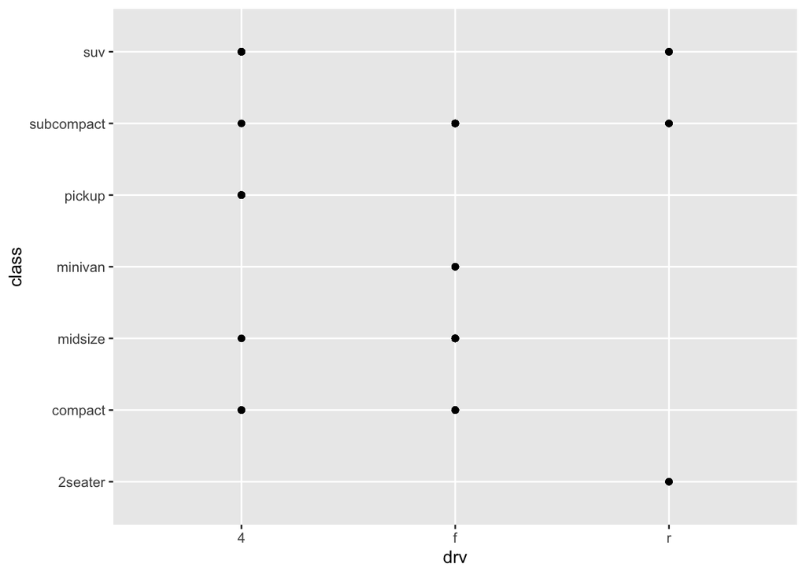

```r
mpg %>%
  ggplot(aes(x = drv, y = class)) +
  geom_point()
```

Porque temos duas variáveis categóricas. Gráficos de dispersão são mais úteis para verificar relações entre variáveis numéricas.

# 2 Exercícios - Pág. 12

## 2.1 What’s gone wrong with this code? Why are the points not blue?

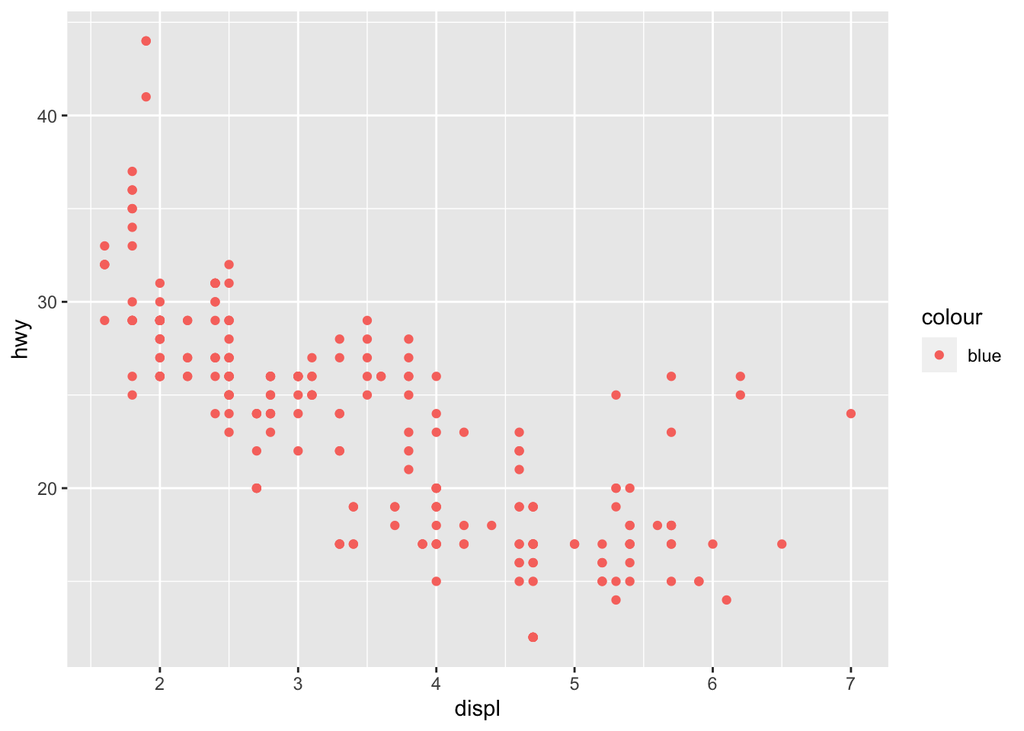

```r
ggplot(data = mpg) +
  geom_point(mapping = aes(x = displ, y = hwy, color = "blue"))
```

## 2.2 Which variables in mpg are categorical? Which variables are continuous? (Hint: type ?mpg to read the documentation for the dataset.) How can you see this information when you run mpg?

## 2.3 Map a continuous variable to color, size, and shape. How do these aesthetics behave differently for categorical versus continuous variables?

## 2.4 What happens if you map the same variable to multiple aesthetics?